# **Task 2 - Regression Using PyTorch - MS4H20**

This notebook covers each section of task 2 for the MS4H20 coursework. First, the relevant libraries are imported below.

```python
import numpy as np
import math
import torch
from IPython.display import display
from PIL import Image as PILImage
```

## Part 1 - Question 1

Using PyTorch and its Autograd feature, calculate dy/dx for each of the following questions, initalising two variables (x & c) each as scaler tensors of a single value = 1, where c is a constant.

Q1: $y=2(3j^3+2j)+c$, where $j=x^2+c$

The below code defines a function for the equation and uses pytorch autograd to calculate the result of the equation for $x = 1, c = 1$, as well as the value of dy/dx. The value is calculated as 152.

```python
def equation(x, c):
    j = x**2 + c
    return 2 * (3*j**3 + 2*j) + c

# Define the input values
x = torch.ones(1, requires_grad = True)
c = torch.ones(1, requires_grad = False)

# Compute the result of the equation
result = equation(x, c)

# Compute the derivative of the result with respect to 'x'
result.backward()

# Access the derivative (gradient) of the result with respect to 'x'
derivative_x = x.grad

print("Result:", result.item())
print("Derivative with respect to 'x':", derivative_x.item())
```

```
Result: 57.0
Derivative with respect to 'x': 152.0
```

## Part 1 - Question 2

Using PyTorch and its Autograd feature, calculate dy/dx for each of the following questions, initalising two variables (x & c) each as scaler tensors of a single value = 1, where c is a constant.

Q2: $y=2q^3+3q^2+5c^4/c^2$, where $q=2x+3x^2+1$

The below code defines a function for the equation and uses pytorch autograd to calculate the result of the equation for $x = 1, c = 1$, as well as the value of dy/dx. The value is calculated as 2016.

```python
def equation(x, c):
    q = 2*x + 3*x**2 + 1
    return (2*q**3) + (3*q**2) + ((5*c**4)/(c*2))

# Define the input values
x = torch.tensor(1.0, requires_grad=True)
c = torch.tensor(1.0, requires_grad=False)

# Compute the result of the equation
result = equation(x, c)

# Compute the derivative of the result with respect to 'x'
result.backward()

# Access the derivative (gradient) of the result with respect to 'x'
derivative_x = x.grad

print("Result:", result.item())
print("Derivative with respect to 'x':", derivative_x.item())
```

```
Result: 542.5
Derivative with respect to 'x': 2016.0
```

## Part 1 - Question 3

Using PyTorch and its Autograd feature, calculate dy/dx for each of the following questions, initalising two variables (x & c) each as scaler tensors of a single value = 1, where c is a constant.

Q3: $y=2t$, where $t=3s^2+2$, $s=4(2r+4r^2 )^2$, $r=q+15$, $q=x^2+2x$

The below code defines a function for the equation and uses pytorch autograd to calculate the result of the equation for $x = 1, c = 1$, as well as the value of dy/dx. The value is calculated as 529976684183552.

```python
def equation(x, c):
    q = x**2 + 2*x
    r = q + 15
    s = 4*(2*r + 4*r**2)**2
    t = 3*s**2 + 2
    return 2*t

# Define the input values
x = torch.tensor(1.0, requires_grad=True)
c = torch.tensor(1.0, requires_grad=False)

# Compute the result of the equation
result = equation(x, c)

# Compute the derivative of the result with respect to 'x'
result.backward()

# Access the derivative (gradient) of the result with respect to 'x'
derivative_x = x.grad

print("Result:", result.item())
print("Derivative with respect to 'x':", derivative_x.item())
```

```
Result: 302195576668160.0
Derivative with respect to 'x': 529976684183552.0
```

## Part 1 - Question 4a

Showing you workings by-hand, calculate the differential equation of y with respect to x (hence calculate, dy/dx) for the following equations: $y=2(3j^3+2j)+c$, where $j=x^2+c$

The image below shows my workings, using the different rules of differentiation to get the answer 152, the same answer computationally achieved above. The derivative was calculated as $36x(x^2 + c)^2 + 8x = 152$

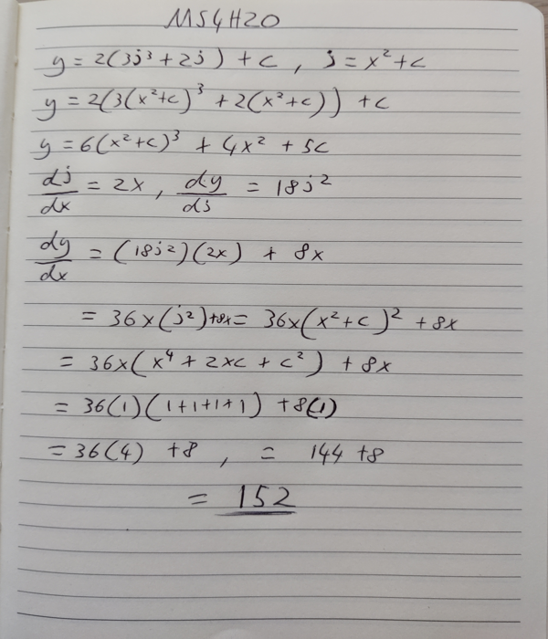

```python
# Open the picture using Pillow
img = PILImage.open('C:/Users/hagu2/OneDrive/Documents/Advanced Skills Data/Q5.jpg')
# Resize the image
resized_img = img.resize((600, 700))
# Display the resized image in the notebook
display(resized_img)
```

## Part 1 - Question 4b

Showing you workings by-hand, calculate the differential equation of y with respect to x (hence calculate, dy/dx) for the following equations: $y=2q^3+3q^2+5c^4/c^2$, where $q=2x+3x^2+1$

The image below shows my workings, using the different rules of differentiation to get the answer 2016, the same answer computationally achieved above. I solved this by differentiating the first half $(2q^3) and the second half (3q^2) separately and then using the sum rule to get the overal value.

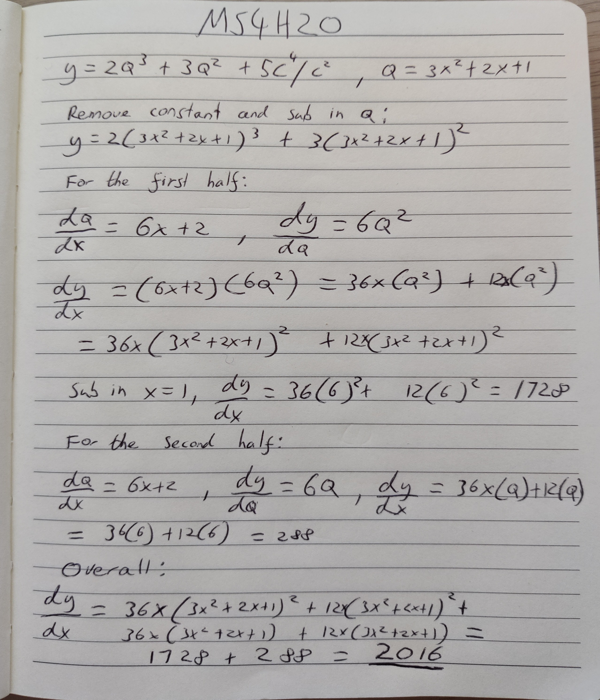

```python
# Open the picture using Pillow
img = PILImage.open('C:/Users/hagu2/OneDrive/Documents/Advanced Skills Data/Q6.jpg')
# Resize the image
resized_img = img.resize((600, 700))
# Display the resized image in the notebook
display(resized_img)
```

## Part 2

Using PyTorch without helper functions (without using torch.nn or torch.optim), calculate the values of a,b & c that best fit the model f(x) to the provided input data X and known labels y_0.

The below code defines a class for gradient descent optimization using pytorch, for fitting a model to a given dataset. This is used to find the best parameters (a, b, and c) for the given equation that fit the model to the known data.

The model by default has a learning rate of 0.1, 1000 iterations, and a convergence threshold of 1e-6, however all of these have been changed when using the model to get the best performance for this problem.

The algorithm optimises the values to be: $a = 0.9912411570549011, b = -6.8641276359558105, c = 3.231455087661743$

With more iterations these values tend to the values: $a = 1, b = -7, c = 3$

```python
import torch

class GradientDescentOptimizer:
    def __init__(self, learning_rate=0.1, num_iterations=1000, convergence_threshold=1e-6):
        self.learning_rate = learning_rate
        self.num_iterations = num_iterations
        self.convergence_threshold = convergence_threshold

    def fit(self, X, y_true):
        # Number of data points
        N = len(X)

        # Initialize parameters (a, b, and c) with random values
        self.a = torch.randn(1, requires_grad=True, dtype=torch.float32)
        self.b = torch.randn(1, requires_grad=True, dtype=torch.float32)
        self.c = torch.randn(1, requires_grad=True, dtype=torch.float32)

        for i in range(self.num_iterations):
            # Step 2: Compute predicted output y_pred using the model f(x)
            y_pred = torch.exp(2 * self.a * X) + self.b * X ** 2 + self.c * X

            # Step 3: Compute MSE loss
            loss = torch.mean((y_pred - y_true) ** 2)

            # Step 4: Compute gradients
            loss.backward()

            # Step 5: Update parameters using gradient descent update rule
            with torch.no_grad():
                self.a -= self.learning_rate * self.a.grad
                self.b -= self.learning_rate * self.b.grad
                self.c -= self.learning_rate * self.c.grad
                self.a.grad.zero_()
                self.b.grad.zero_()
                self.c.grad.zero_()

            # Print the loss at every 100 iterations
            if i % 100 == 0:
                print(f"Iteration {i}, Loss: {loss.item()}")

            # Check for convergence
            if i > 0:
                prev_loss = loss_history[-1]
                if abs(prev_loss - loss.item()) < self.convergence_threshold:
                    print("Converged!")
                    break

            loss_history.append(loss.item())

# Given data
X = torch.tensor([-2, -1.75, -1.5, -1.25, -1, -0.75, -0.5, -0.25, 0, 0.25, 0.5, 0.75, 1, 1.25, 1.5, 1.75], dtype=torch.float32)
y_true = torch.tensor([-33.982, -26.657, -20.2, -14.605, -9.865, -5.964, -2.882, -0.581, 1.0, 1.961, 2.468, 2.794, 3.389, 4.995, 8.836, 16.928], dtype=torch.float32)

# Create the optimizer object
optimizer = GradientDescentOptimizer(learning_rate=0.0007, num_iterations=50000, convergence_threshold=1e-5)

# Loss history for convergence check
loss_history = []

# Fit the model to the data
optimizer.fit(X, y_true)

# Get the final values of a, b, and c
a, b, c = optimizer.a.item(), optimizer.b.item(), optimizer.c.item()

print("Final values of a, b, and c:", a, b, c)
```

```
Iteration 0, Loss: 171.72203063964844
Iteration 100, Loss: 75.43414306640625
Iteration 200, Loss: 33.55315017700195
Iteration 300, Loss: 15.049606323242188
Iteration 400, Loss: 6.864524841308594
Iteration 500, Loss: 3.2367866039276123
Iteration 600, Loss: 1.6226004362106323
Iteration 700, Loss: 0.8984656929969788
Iteration 800, Loss: 0.5680927634239197
Iteration 900, Loss: 0.41223520040512085
Iteration 1000, Loss: 0.3340212106704712
Iteration 1100, Loss: 0.29063543677330017
Iteration 1200, Loss: 0.26313257217407227
Iteration 1300, Loss: 0.24311727285385132
Iteration 1400, Loss: 0.22685657441616058
Iteration 1500, Loss: 0.21267905831336975
Iteration 1600, Loss: 0.19982090592384338
Iteration 1700, Loss: 0.18792219460010529
Iteration 1800, Loss: 0.17680639028549194
Iteration 1900, Loss: 0.16637229919433594
Iteration 2000, Loss: 0.15655829012393951
Iteration 2100, Loss: 0.1473187953233719
Iteration 2200, Loss: 0.13861693441867828
Iteration 2300, Loss: 0.1304209679365158
Iteration 2400, Loss: 0.12270095944404602
Iteration 2500, Loss: 0.1154305562376976
Iteration 2600, Loss: 0.10858327150344849
Iteration 2700, Loss: 0.1021355390548706
Iteration 2800, Loss: 0.09606504440307617
Iteration 2900, Loss: 0.09034926444292068
Iteration 3000, Loss: 0.08496849983930588
Iteration 3100, Loss: 0.07990380376577377
Iteration 3200, Loss: 0.07513606548309326
Iteration 3300, Loss: 0.07064957171678543
Iteration 3400, Loss: 0.0664273053407669
Iteration 3500, Loss: 0.06245402991771698
Iteration 3600, Loss: 0.058715566992759705
Iteration 3700, Loss: 0.055198416113853455
Iteration 3800, Loss: 0.051889143884181976
Iteration 3900, Loss: 0.04877641797065735
Iteration 4000, Loss: 0.04584820941090584
Iteration 4100, Loss: 0.04309454932808876
Iteration 4200, Loss: 0.04050430655479431
Iteration 4300, Loss: 0.03806791454553604
Iteration 4400, Loss: 0.035776883363723755
Iteration 4500, Loss: 0.03362268954515457
Iteration 4600, Loss: 0.031596839427948
Iteration 4700, Loss: 0.029692085459828377
Iteration 4800, Loss: 0.02790156379342079
Iteration 4900, Loss: 0.026217838749289513
Iteration 5000, Loss: 0.024635305628180504
Iteration 5100, Loss: 0.023147180676460266
Iteration 5200, Loss: 0.021748512983322144
Iteration 5300, Loss: 0.02043379656970501
Iteration 5400, Loss: 0.01919790916144848
Iteration 5500, Loss: 0.01803654618561268
Iteration 5600, Loss: 0.016944704577326775
Converged!
Final values of a, b, and c: 0.9912411570549011 -6.8641276359558105 3.231455087661743
```

To validate the results of the above code, I have inputted the values of $a = 1, b = -7, c = 3$ to the equation for the first and last known values of x, to compare to the first and last known values of y. The results show that those values provide the same coordinates as provided in the question, validating the parameter values.

```python
y1 = math.exp(-4) + (-28) + (-6)
y_final = math.exp(3.5) + (-21.4375) + (5.25)
print(-2, y1)
print(1.75, y_final)
```

```
-2 -33.98168436111126
1.75 16.92795195869231
```